# BikeFlow: Investigating-User-Behavior-in-the-FordGo-Bike-Sharing-Network

### by

## Shedrack David

## Investigation Overview

This investigation studies when most trips taken in terms of time of day or month of the year and How long average trip take and if this depend on wheather the user is a subscriber or a customer?

FordGo is a regional public bicycle sharing system in California's San Francisco Bay Area. It is operated by Motivate in a partnership with the Metropolitan Transportation Commission and the Bay Area Air Quality Management District. Bay Wheels is 'the first regional and large-scale bicycle sharing system deployed in California and on the West Coast of the United States. It was established as Bay Area Bike Share in August 2013. the system was officially re-launched as Ford GoBike in a partnership with Ford Motor Company. After Motivate's acquisition by Lyft, the system was renamed to Bay Wheels on June 11, 2019. This investigation explores a dataset containing FordGo's trip data for each month in the year 2019.

## Dataset Overview

There are over 2,000,000 trips in the dataset with 9 features:

- duration
- start_time
- end_time
- is_weekend
- user_is_subscriber
- trip_time_of_day
- start_month time_diff
- start_station_name
- end_station_name

# Usage Trends and Patterns

## User Groups

FordGo or Bay Wheels differentiate between two user groups; "Subscribers" who are members of an annual or a monthly plan, and "Customers" who pay for each single trip. During the investigation period, 80.7% of users were "Subscribers", while 19.3% were "Customers".

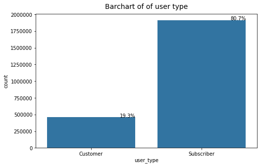

## Time of Day Demand

A question of interest for this analysis is to know when when most trips taken in terms of time of day or month of the year, From investigating the dataset

most trips are taken at late hour of the day

most trips are taken during weekdays rather than weekends. thursdays and tuesdays are the most prefered days to take a trip.

on average, trips on weekends tend to be slightly longer than on weekdays and has less outliers and more spread distribution

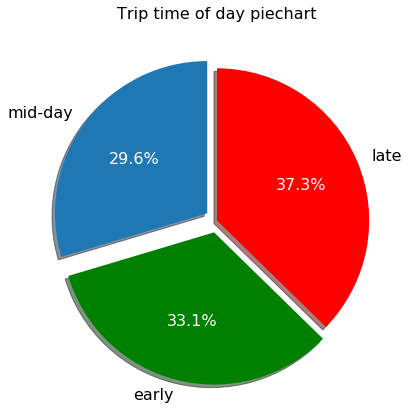

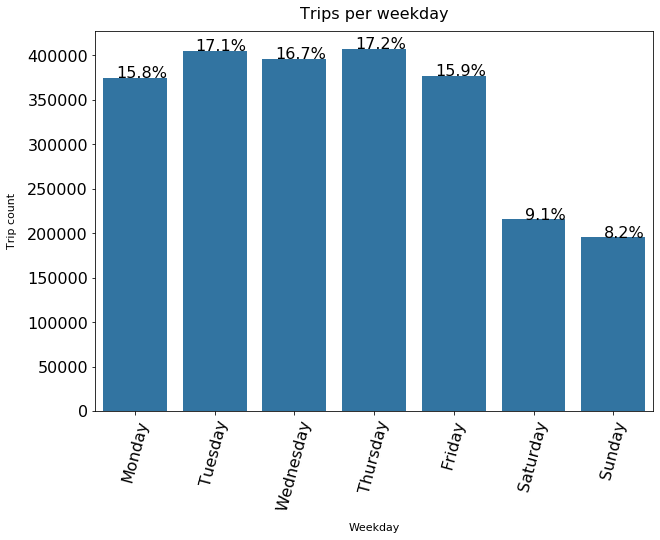

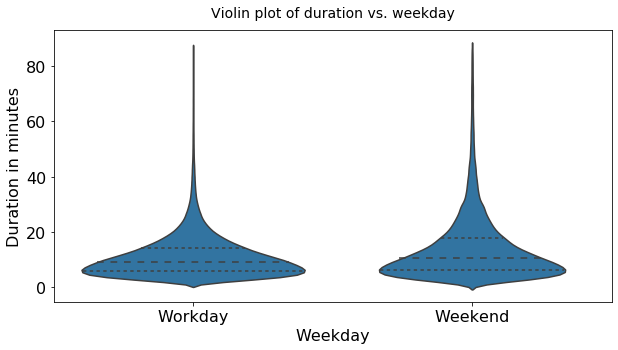

## Monthly Demand

Most trips were taken in the month of March and April but drastically drops in the month of December.

changes in monthly trips count tended to be similar for both user groups; this pattern persists till November and in the month of December, the number of "Customers" became, higher than this of "Subscribers".

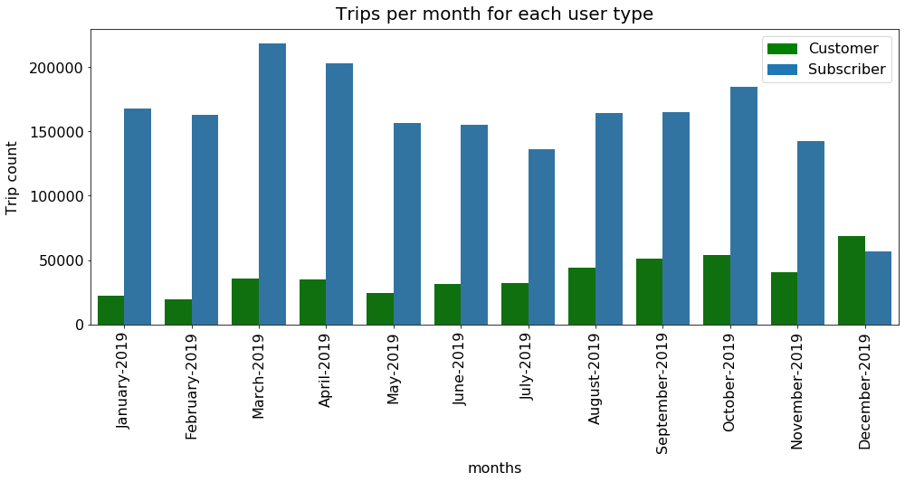

## Demand Fluctuations For Both User types

for both users, trips peak around the hours of 8-9am and 5-6pm but drops around 10am - 3pm. though it seems to drop more significantly for subscribers

customer's trips tends to peak on the 12th, 13th and 19th day but seems to drop significantly on the 14th and 15th day, while for subscribers, it peaks on the 11th and 12th day but drops on the 15th and 27th day

subscribers trips peaks mostly on weekdays but significantly drops on weekends while customers demand seem consistent accross the entire week, we could assume that most subscribers use bikes to and from their works based on our findings for trips per hour

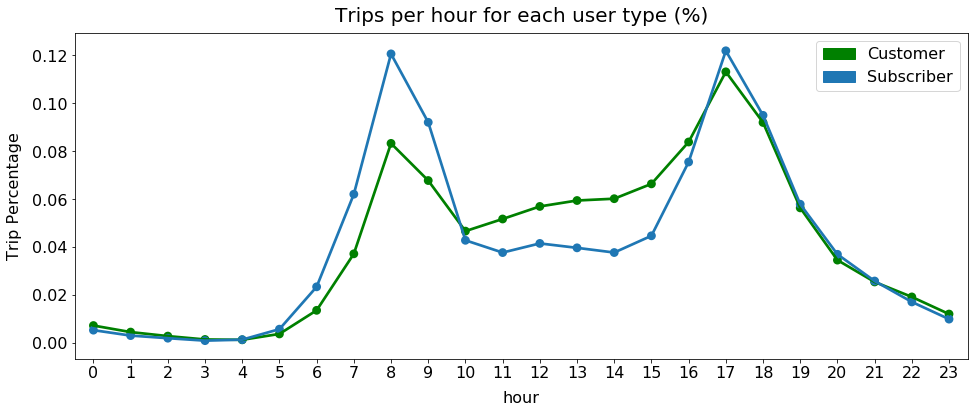

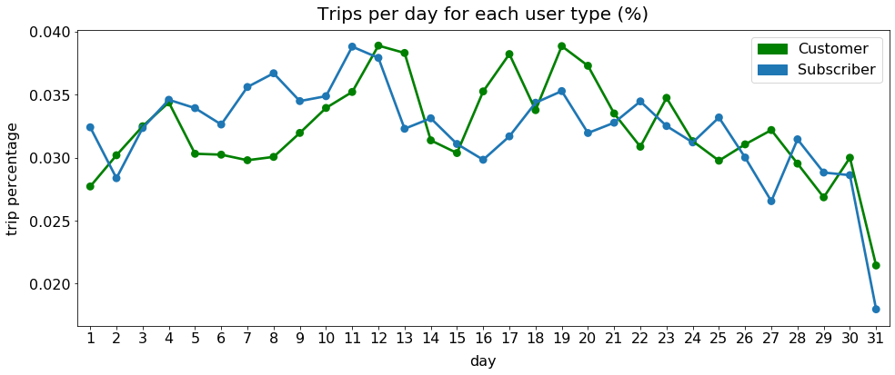

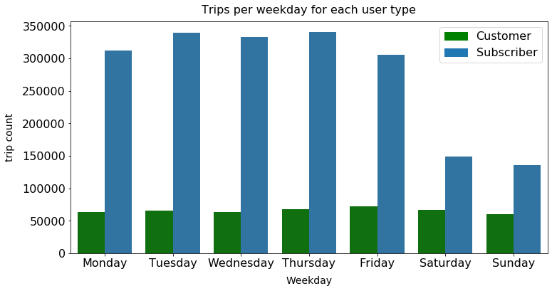

# Determinants of Trip Duration

## Distribution of Trip Durations

Trip durations in the dataset ranges from 1minute to about 90minutes. The distribution is right-skewed on a linear scale but when plotted on a logarithmic scale, the distribution of trip durations gets closer to normal but with a rough shape.

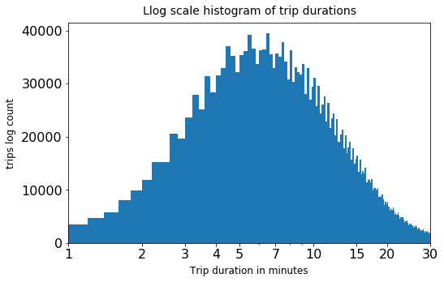

## Trip Duration and User Groups Usage Through the Week/Month

Customers tend to have more duration in their trips than Subscribers and their distribution also have more spread compared to Subscribers. In other words, Customers tend to vary their trip durations, while Subscribers mostly use the service for short trips.

Duration distribution has more spread on weekends for both user types but is more apparent for Customers, and the meadian trip duration for Customers has more spread which means Customers tend, on average, to take longer trips, and their trips' durations vary more compared to Subscribers.

[figure not shown]

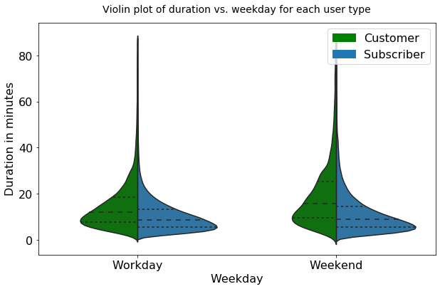

[figure not shown]